# Regressão linear e intervalos de confiança usando R

Fabio M. Torres

02/05/2020

Nesse projeto vou explorar o uso da **linguagem R** para criar modelos de **Regressão Linear Simples** (Método dos Mínimos Quadrados) e calcular o **intervalo de confiança** para os coeficientes calculados, além disso, comentar como interpretar as informações obtidas no modelo.

Vou usar o exemplo abaixo para demonstrar:

*Um estudo relacionou a idade das crianças com a sua altura. Para isso, foi realizado um levantamento com 50 crianças. Os dados obtidos estão apresentados na sequência.*

| Criança | Sexo* | Idade (meses) | Altura (cm) |
| --- | --- | --- | --- |
| 1 | F | 1 | 48 |
| 2 | M | 1 | 60 |
| 3 | F | 2 | 51 |
| 4 | M | 3 | 65 |
| 5 | M | 3 | 63 |
| 6 | F | 5 | 54 |
| 7 | F | 5 | 59 |
| 8 | M | 6 | 69 |
| 9 | F | 7 | 63 |
| 10 | M | 7 | 71 |
| 11 | F | 7 | 65 |
| 12 | F | 8 | 62 |
| 13 | M | 8 | 76 |
| 14 | F | 9 | 67 |
| 15 | F | 11 | 71 |
| 16 | M | 12 | 78 |
| 17 | F | 13 | 70 |
| 18 | M | 14 | 80 |
| 19 | F | 15 | 68 |
| 20 | F | 15 | 70 |
| 21 | M | 16 | 83 |
| 22 | M | 17 | 84 |
| 23 | M | 17 | 84 |
| 24 | F | 18 | 72 |
| 25 | F | 18 | 74 |
| 26 | M | 19 | 88 |
| 27 | F | 20 | 76 |
| 28 | F | 21 | 70 |
| 29 | F | 22 | 75 |
| 30 | M | 22 | 86 |
| 31 | F | 23 | 79 |
| 32 | M | 25 | 88 |
| 33 | M | 26 | 91 |
| 34 | F | 26 | 78 |
| 35 | M | 27 | 95 |
| 36 | M | 27 | 93 |
| 37 | F | 28 | 86 |
| 38 | F | 29 | 85 |
| 39 | M | 29 | 96 |
| 40 | F | 31 | 86 |
| 41 | M | 31 | 95 |
| 42 | M | 32 | 93 |
| 43 | F | 32 | 87 |
| 44 | M | 33 | 96 |
| 45 | M | 34 | 98 |
| 46 | M | 34 | 95 |
| 47 | M | 34 | 98 |
| 48 | F | 35 | 89 |
| 49 | F | 36 | 90 |
| 50 | M | 36 | 99 |

*M: Masculino, F: Feminino

## Regressão Linear

A primeira coisa a se fazer é colocar os dados em um *data frame* para facilitar a manipulação.

```r
# Criando os vetores
sexo <- c("F", "M", "F", "M", "M", "F", "F", "M", "F", "M", "F", "F", "M", "F", "F", "M", "F", "M", "F", "F", "M", "M", "M", "F", "F", "M", "F", "F", "F", "M", "F", "M", "M", "F", "M", "M", "F", "F", "M", "F", "M", "M", "F", "M", "M", "M", "M", "F", "F", "M")

idade <- c(1, 1, 2, 3, 3, 5, 5, 6, 7, 7, 7, 8, 8, 9, 11, 12, 13, 14, 15, 15, 16, 17, 17, 18, 18, 19, 20, 21, 22, 22, 23, 25, 26, 26, 27, 27, 28, 29, 29, 31, 31, 32, 32, 33, 34, 34, 34, 35, 36, 36)

altura <- c(48, 60, 51, 65, 63, 54, 59, 69, 63, 71, 65, 62, 76, 67, 71, 78, 70, 80, 68, 70, 83, 84, 84, 72, 74, 88, 76, 70, 75, 86, 79, 88, 91, 78, 95, 93, 86, 85, 96, 86, 95, 93, 87, 96, 98, 95, 98, 89, 90, 99)

# Concatenando os vetores em um data frame
df <- data.frame(sexo, idade, altura)

# Deletando os vetores
rm(idade, altura, sexo)
```

Com os dados organizados, vamos visualizá-los em um **gráfico de dispersão** (usando a função`ggplot()`):

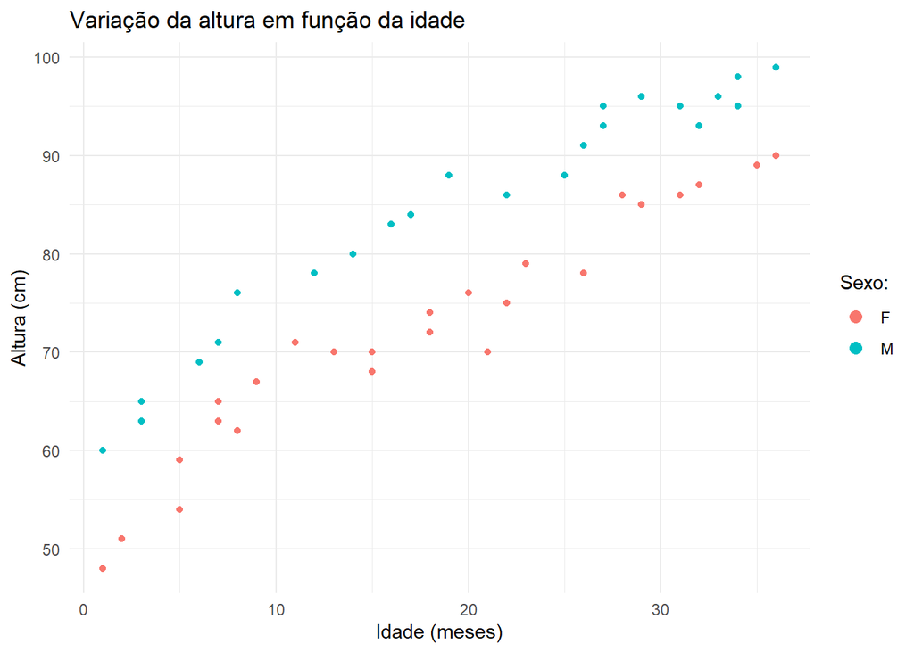

```r
# Carregar o pacote ggplot2 com as funções para gráficos
library(ggplot2)

ggplot(data = df, aes(x = idade, y = altura, colour = as.factor(sexo))) +
      geom_point() +
      theme_minimal() +
      labs(title = "Variação da altura em função da idade", x="Idade (meses)",
           y="Altura (cm)",
           colour = "Sexo:") +
      theme(legend.position = "right") +
      guides(colour = guide_legend(nrow = 2, override.aes = list(size = 3)))
```

Verificamos visualmente pelo gráfico que conforme a idade aumenta a variável altura tende a aumentar também, de maneira aproximadamente linear.

Vamos agora ver matematicamente o nível de correlação entre as variáveis, calculando o **coeficiente de correlação de Pearson**. Para isso usamos a função `cor()`.

```r
cor(df$idade[df$sexo=="F"], df$altura[df$sexo=="F"], method = "pearson")
```

```
## [1] 0.9642975
```

```r
cor(df$idade[df$sexo=="M"], df$altura[df$sexo=="M"], method = "pearson")
```

```
## [1] 0.9749748
```

O coeficiente de correlação para crianças do sexo feminino vale aproximadamente 0.96. E o coeficiente de correlação para crianças do sexo masculino vale aproximadamente 0.97. Isso indica uma forte correlação positiva entre idade e altura.

Agora que já sabemos o comportamento das duas variáveis faz sentido ajustar um modelo de regressão linear aos dados, ou seja, procurar a equação da reta que melhor se ajusta aos pontos no gráfico. A função `lm()` nos permite criar um modelo de regressão linear e armazená-lo, a partir do modelo obtemos diversas informações, entre elas, os coeficientes da equação da reta, os principais argumentos da função são:

`lm(variavel_dependente ~ variavel_independente)`

Para saber mais sobre a função e seus demais argumentos, você pode digitar `?lm()` na janela console do **RStudio**.

```r
# Armazenando o modelo dos dados de crianças do sexo feminino:
rlf <- lm(df$altura[df$sexo=="F"] ~ df$idade[df$sexo=="F"])

# Visualizar as informações do modelo:
summary(rlf)
```

```
##
## Call:
## lm(formula = df$altura[df$sexo == "F"] ~ df$idade[df$sexo ==
##     "F"])
##
## Residuals:
##     Min      1Q  Median      3Q     Max
## -6.2420 -1.5315  0.3001  1.6460  6.1039
##
## Coefficients:
##                          Estimate Std. Error t value Pr(>|t|)
## (Intercept)              53.17654    1.24118   42.84  < 2e-16 ***
## df$idade[df$sexo == "F"]  1.06542    0.06101   17.46 9.09e-15 ***
## ---
## Signif. codes:  0 '***' 0.001 '**' 0.01 '*' 0.05 '.' 0.1 ' ' 1
##
## Residual standard error: 3.175 on 23 degrees of freedom
## Multiple R-squared:  0.9299, Adjusted R-squared:  0.9268
## F-statistic:   305 on 1 and 23 DF,  p-value: 9.094e-15
```

Utilizando a função `summary()` obtemos algumas informações importantes sobre o modelo:

- *Residuals:* se refere ao conjunto das diferenças entre cada ponto do conjunto de dados e a reta de regressão, que são:
  - Valor mínimo (*Min*): -6.2420
  - 1° Quartil (*1Q*): -1.5315
  - Mediana (*Median*): 0.3001
  - 3° Quartil (*3Q*): 1.6460
  - Valor máximo (*Max*): 6.1039
- Quando usamos regressão linear estamos em busca da reta que melhor se ajusta aos pontos que vimos no gráfico de dispersão, lembrando que a **equação de uma reta** é da forma *y=a + bx* temos que os coeficientes da nossa reta (em *Coefficients*, na coluna *Estimate*) são:
  - *a*= 53.17654 (**Coeficiente linear** | onde a reta **intercepta** o eixo y, quando x=0)
  - *b*= 1.06542 (**Coeficiente angular** | Inclinação da reta)
- A coluna *Std. Error* é o desvio padrão residual relacionado a cada coeficiente calculado (estimado), esse parâmetro serve para calcular os intervalos de confiança para cada coeficiente;
- A coluna *t value* é a medida de quantos desvios padrão a estimativa de coefeciente está longe de zero, esse dado pode ser usado para calcular o *p-valor*;
- A coluna *Pr(>|t|)* nos diz a probabilidade de encontrar qualquer valor maior que o módulo de *t*. Observa-se que a indicação de três asteriscos para os dois coeficientes representam um *p-valor* altamente significativo, o que reforça a hipótese de que há uma correlação entre as variáveis;
- O desvio padrão residual é de 3.175 para 23 graus de liberdade (n-2 sendo nosso n = 25, por que estamos considerando apenas as crianças do sexo feminino);
- *Multiple R-squared* é o valor do **coeficiente de determinação (R²)**, que nos diz que 92.99% da variação da altura é explicada pela variação da idade. Como o valor de R² aumenta a medida que mais variáveis são incluídas no modelo, R² ajustado é preferível, por se ajustar ao número de variáveis consideradas;
- *F-statistic* pode ser utilizado para saber se existe relação real entre as variáveis preditora e resposta.

Vamos agora criar mais um modelo de **r**egressão **l**inear, mas dessa vez para os dados das crianças do sexo **m**asculino (vamos armazenar em **rlm**):

```r
# Armazenando o modelo dos dados de crianças do sexo masculino:
rlm <- lm(df$altura[df$sexo=="M"] ~ df$idade[df$sexo=="M"])

# Visualizar as informações do modelo:
summary(rlm)
```

```
##
## Call:
## lm(formula = df$altura[df$sexo == "M"] ~ df$idade[df$sexo ==
##     "M"])
##
## Residuals:
##     Min      1Q  Median      3Q     Max
## -5.0791 -1.6707 -0.4674  2.4032  4.5881
##
## Coefficients:
##                          Estimate Std. Error t value Pr(>|t|)
## (Intercept)              64.06063    1.13049   56.67   <2e-16 ***
## df$idade[df$sexo == "M"]  1.01849    0.04842   21.03   <2e-16 ***
## ---
## Signif. codes:  0 '***' 0.001 '**' 0.01 '*' 0.05 '.' 0.1 ' ' 1
##
## Residual standard error: 2.695 on 23 degrees of freedom
## Multiple R-squared:  0.9506, Adjusted R-squared:  0.9484
## F-statistic: 442.4 on 1 and 23 DF,  p-value: < 2.2e-16
```

## Intervalos de Confiança

Com a função `ggplot()` podemos plotar um gráfico com a reta de regressão e que por meio da área mais escura indica o **erro padrão da reta**, para facilitar a visualização separei os dados de meninas e meninos em gráficos separados.

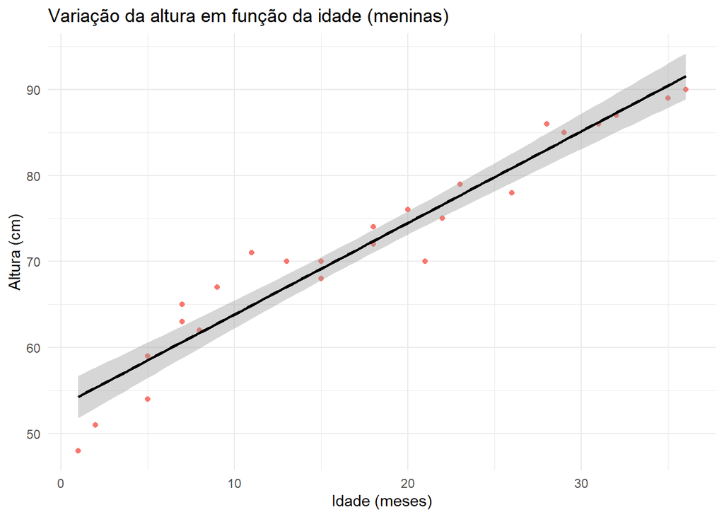

```r
# Organizando os dados das meninas em um novo data set:
idade <- df$idade[df$sexo=="F"]
altura <- df$altura[df$sexo=="F"]
feminino <- data.frame(idade, altura)

# Plotando o gráfico
ggplot(data = feminino, aes(x = idade, y = altura)) +
      geom_point(color="#F8766D") +
      geom_smooth(method=lm, colour="black") +
      theme_minimal() +
      labs(title = "Variação da altura em função da idade (meninas)", x="Idade (meses)",
           y="Altura (cm)") +
      guides(colour = guide_legend(nrow = 2, override.aes = list(size = 3)))
```

Abaixo temos o mesmo procedimento, mas para crianças do sexo masculino.

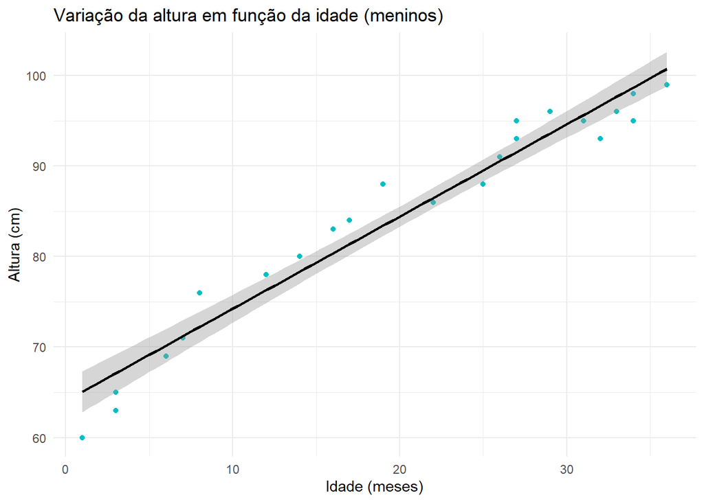

```r
# Organizando os dados dos meninos em um novo data set:
idade <- df$idade[df$sexo=="M"]
altura <- df$altura[df$sexo=="M"]
masculino <- data.frame(idade, altura)
rm(idade, altura)

# Plotando o gráfico
ggplot(data = masculino, aes(x = idade, y = altura)) +
      geom_point(color="#00BFC4") +
      geom_smooth(method=lm, colour="black") +
      theme_minimal() +
      labs(title = "Variação da altura em função da idade (meninos)", x="Idade (meses)",
           y="Altura (cm)") +
      guides(colour = guide_legend(nrow = 2, override.aes = list(size = 3)))
```

A linguagem R ainda nos permite facilmente calcular os **intervalos de confiança para os coeficientes**, usando a função `confint()`. Abaixo esse cálculo é feito para o modelo criado com os dados das crianças do sexo feminino, com um **nível de confiança de 95%**:

```r
confint(rlf, level = 0.95)
```

```
##                               2.5 %    97.5 %
## (Intercept)              50.6089693 55.744116
## df$idade[df$sexo == "F"]  0.9392075  1.191623
```

Abaixo temos os dados obtidos acima comparados com o valor que foi estimado pelo modelo para as **meninas**:

| Coeficientes | Valor Mínimo | Valor Estimado | Valor Máximo |
| --- | --- | --- | --- |
| Coeficiente linear *a* | 50.6089693 | 53.17654 | 55.744116 |
| Coeficiente angular *b* | 0.9392075 | 1.06542 | 1.191623 |

Fazendo os mesmos procedimentos para o modelo criado para os meninos obtemos:

```r
confint(rlm, level = 0.95)
```

```
##                               2.5 %    97.5 %
## (Intercept)              61.7220333 66.399223
## df$idade[df$sexo == "M"]  0.9183135  1.118662
```

Abaixo temos os dados obtidos acima comparados com o valor que foi estimado pelo modelo para os **meninos**:

| Coeficientes | Valor Mínimo | Valor Estimado | Valor Máximo |
| --- | --- | --- | --- |
| Coeficiente linear *a* | 61.7220333 | 64.06063 | 66.399223 |
| Coeficiente angular *b* | 0.9183135 | 1.01849 | 1.118662 |

Espero que esse artigo seja útil para auxiliar nas suas análises! se você deseja se aprofundar mais no assunto recomendo uma olhada na bibliografia abaixo. E se você também se interessa por análise de dados com python, não deixe de dar uma olhada no meu [artigo sobre os dados do Airbnb](https://medium.com/@fabiomendes_95615/hong-kong-airbnb-e-covid-19-7e2828dd3fa).

*Saiba mais sobre meus projetos nas plataformas abaixo:*

[LinkedIn](https://www.linkedin.com/in/fabio-mendes-35743b128)

[Medium](https://medium.com/@fabiomendes_95615)

[GitHub](https://github.com/fabioTowers)

### Bibliografia:

VIEIRA, S. **Introdução a Bioestatística**. 5ª ed. Rio de Janeiro: Elsevier, 2016.

*LINEAR REGRESSION CONFIDENCE INTERVALS*. Disponível em: https://rpubs.com/aaronsc32/regression-confidence-prediction-intervals. Acesso em: 16 mai. 2020.

*SIMPLE LINEAR REGRESSION*. Disponível em: https://rpubs.com/aaronsc32/simple-linear-regression. Acesso em: 16 mai. 2020.

*QUICK GUIDE: INTERPRETING SIMPLE LINEAR MODEL OUTPUT IN R*. Disponível em: https://feliperego.github.io/blog/2015/10/23/Interpreting-Model-Output-In-R. Acesso em: 16 mai. 2020.

*ESTATÍSTICA - AULA 26 - EXERCÍCIOS SOBRE CORRELAÇÃO*. Disponível em: https://youtu.be/sKchGCUYJ5A. Acesso em: 16 mai. 2020.